# dropouts

## Looking at the data

We plot the data and can see that there is no obvious large difference between the debt versions. We do however see a defference when it comes to which scenario the droput was on.

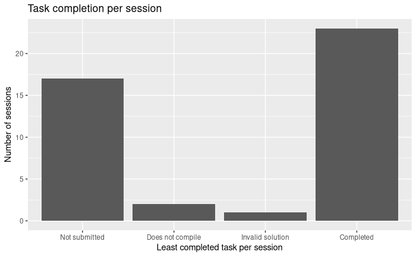

```r
d.sessions %>%
  ggplot(aes(task_completion)) +
  geom_bar() +
  labs(title = "Task completion per session") +
  xlab("Least completed task per session") +
  ylab("Number of sessions")
```

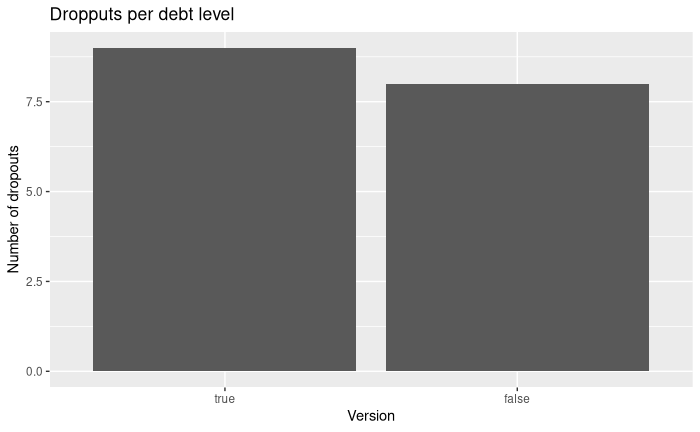

```r
d %>%
  filter(task_completion == "Not submitted") %>%
  group_by(high_debt_version) %>%
  summarise(n = n()) %>%
  ggplot(aes(x=high_debt_version, y=n)) +
  geom_bar(stat = "identity") +
  # geom_text(aes(label=n), vjust=1.7, size=5, color = "white") +
  labs(title = "Dropputs per debt level") +
  xlab("Version") +
  ylab("Number of dropouts")
```

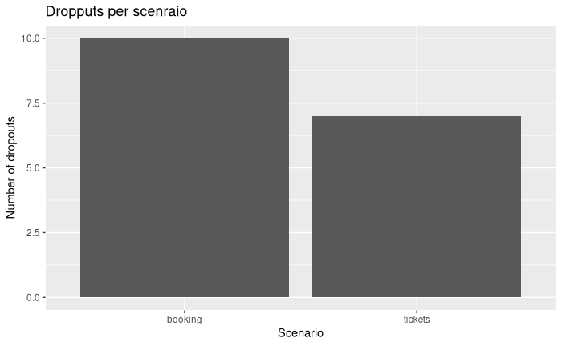

```r
d %>%
  filter(task_completion == "Not submitted") %>%
  ggplot(aes(scenario)) +
  geom_bar() +
  labs(title = "Dropputs per scenraio") +
  ylab("Number of dropouts") +
  xlab("Scenario")
```

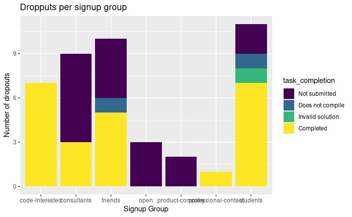

```r
d.sessions %>%
  ggplot(aes(group, fill=task_completion)) +
  geom_bar() +
  labs(title = "Dropputs per signup group") +
  ylab("Number of dropouts") +
  xlab("Signup Group")
```

## Initial model

The outcome model represent incremental steps and will therfore be modeled with stopping ratio

We include `high_debt_verison` in our initial model.

### Selecting Priors

We iterate over the model until we have sane priors

```r
dropouts0.with <- extendable_model(
  base_name = "dropouts0",
  base_formula = "task_completion ~ 1 + high_debt_version",
  base_priors = c(
    prior(normal(0, 1), class = "b"),
    prior(normal(-2, 1), class = "Intercept")
  ),
  family = sratio(),
  data = d,
  # base_control = list(adapt_delta = 0.95)
)

# Default priors:
prior_summary(dropouts0.with(only_priors= TRUE))
```

```
                prior     class                   coef group resp dpar nlpar bound       source
               (flat)         b                                                         default
               (flat)         b high_debt_versionfalse                             (vectorized)
 student_t(3, 0, 2.5) Intercept                                                         default
 student_t(3, 0, 2.5) Intercept                      1                             (vectorized)
 student_t(3, 0, 2.5) Intercept                      2                             (vectorized)
 student_t(3, 0, 2.5) Intercept                      3                             (vectorized)
```

```r
# Our priors:
prior_summary(dropouts0.with(sample_prior = "only"))
```

[output not shown]

[output cut: 88 more lines]

[output not shown]

[output not shown]

[output cut: 43 more lines]

[output not shown]

```
         prior     class                   coef group resp dpar nlpar bound       source
  normal(0, 1)         b                                                            user
  normal(0, 1)         b high_debt_versionfalse                             (vectorized)
 normal(-2, 1) Intercept                                                            user
 normal(-2, 1) Intercept                      1                             (vectorized)
 normal(-2, 1) Intercept                      2                             (vectorized)
 normal(-2, 1) Intercept                      3                             (vectorized)
```

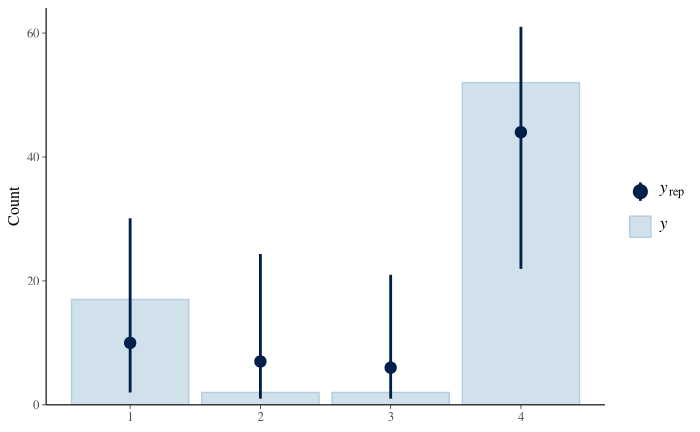

```r
# Prior predictive check
pp_check(dropouts0.with(sample_prior = "only"), nsamples = 200, type = "bars")
```

### Model fit

We check the posterior distribution and can see that the model seems to have been able to fit the data well

[output not shown]

[output cut: 158 more lines]

[output not shown]

[output not shown]

[output cut: 43 more lines]

[output not shown]

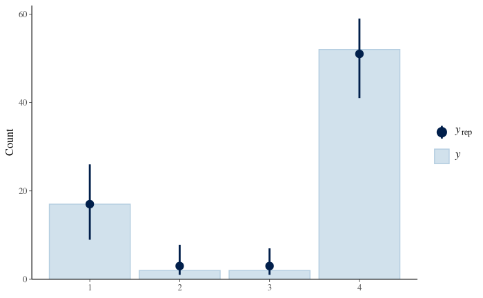

```r
# Posterior predictive check
pp_check(dropouts0.with(), nsamples = 100, type = "bars")
```

```r
summary(dropouts0.with())
```

```
 Family: sratio
  Links: mu = logit; disc = identity
Formula: task_completion ~ 1 + high_debt_version
   Data: as.data.frame(data) (Number of observations: 73)
Samples: 4 chains, each with iter = 2000; warmup = 1000; thin = 1;
         total post-warmup samples = 4000

Population-Level Effects:
                       Estimate Est.Error l-95% CI u-95% CI Rhat Bulk_ESS Tail_ESS
Intercept[1]              -1.16      0.34    -1.87    -0.51 1.00     4751     2861
Intercept[2]              -2.88      0.55    -4.10    -1.86 1.00     4594     2735
Intercept[3]              -2.87      0.57    -4.07    -1.85 1.00     3711     2713
high_debt_versionfalse     0.26      0.43    -0.62     1.10 1.00     4341     2987

Family Specific Parameters:
     Estimate Est.Error l-95% CI u-95% CI Rhat Bulk_ESS Tail_ESS
disc     1.00      0.00     1.00     1.00 1.00     4000     4000

Samples were drawn using sample(hmc). For each parameter, Bulk_ESS
and Tail_ESS are effective sample size measures, and Rhat is the potential
scale reduction factor on split chains (at convergence, Rhat = 1).
```

## Model extenstions

We use loo to check some possible extensions on the model.

```r
edlvl_prior <- prior(dirichlet(2), class = "simo", coef = "moeducation_level1")

loo(
  dropouts0.with(),
  dropouts0.with("work_domain"),
  dropouts0.with("work_experience_programming.s"),
  dropouts0.with("work_experience_java.s"),
  dropouts0.with("education_field"),
  dropouts0.with("mo(education_level)", edlvl_prior),
  dropouts0.with("workplace_peer_review"),
  dropouts0.with("workplace_td_tracking"),
  dropouts0.with("workplace_pair_programming"),
  dropouts0.with("workplace_coding_standards"),
  dropouts0.with("scenario"),
  dropouts0.with("group"),
  dropouts0.with("order")
)
```

[output not shown]

[output cut: 116 more lines]

[output not shown]

[output not shown]

[output cut: 43 more lines]

[output not shown]

[output not shown]

[output cut: 88 more lines]

[output not shown]

[output not shown]

[output cut: 43 more lines]

[output not shown]

[output not shown]

[output cut: 165 more lines]

[output not shown]

[output not shown]

[output cut: 43 more lines]

[output not shown]

[output not shown]

[output cut: 84 more lines]

[output not shown]

[output not shown]

[output cut: 43 more lines]

[output not shown]

[output not shown]

[output cut: 107 more lines]

[output not shown]

[output not shown]

[output cut: 43 more lines]

[output not shown]

[output not shown]

[output cut: 179 more lines]

[output not shown]

[output not shown]

[output cut: 43 more lines]

[output not shown]

[output not shown]

[output cut: 158 more lines]

[output not shown]

[output not shown]

[output cut: 43 more lines]

[output not shown]

[output not shown]

[output cut: 84 more lines]

[output not shown]

[output not shown]

[output cut: 43 more lines]

[output not shown]

[output not shown]

[output cut: 156 more lines]

[output not shown]

[output not shown]

[output cut: 43 more lines]

[output not shown]

[output not shown]

[output cut: 81 more lines]

[output not shown]

[output not shown]

[output cut: 43 more lines]

[output not shown]

[output not shown]

[output cut: 149 more lines]

[output not shown]

[output not shown]

[output cut: 43 more lines]

[output not shown]

[output not shown]

[output cut: 149 more lines]

[output not shown]

[output not shown]

[output cut: 46 more lines]

```
Chain 4 Iteration: 1900 / 2000 [ 95%]  (Sampling)
Chain 4 Iteration: 2000 / 2000 [100%]  (Sampling)
Chain 1 finished in 0.6 seconds.
Chain 3 finished in 0.6 seconds.
Chain 4 finished in 0.6 seconds.
Chain 2 Iteration: 1900 / 2000 [ 95%]  (Sampling)
Chain 2 Iteration: 2000 / 2000 [100%]  (Sampling)
Chain 2 finished in 0.8 seconds.

All 4 chains finished successfully.
Mean chain execution time: 0.7 seconds.
Total execution time: 0.9 seconds.
Output of model 'dropouts0.with()':

Computed from 4000 by 73 log-likelihood matrix
```

|  | Estimate | SE |
| --- | --- | --- |
| elpd_loo | -59.9 | 7.0 |
| p_loo | 2.9 | 0.5 |
| looic | 119.7 | 14.0 |

```
------
Monte Carlo SE of elpd_loo is 0.0.

All Pareto k estimates are good (k < 0.5).
See help('pareto-k-diagnostic') for details.

Output of model 'dropouts0.with("work_domain")':

Computed from 4000 by 73 log-likelihood matrix
```

|  | Estimate | SE |
| --- | --- | --- |
| elpd_loo | -61.7 | 7.2 |
| p_loo | 9.0 | 1.1 |
| looic | 123.5 | 14.5 |

```
------
Monte Carlo SE of elpd_loo is 0.0.

All Pareto k estimates are good (k < 0.5).
See help('pareto-k-diagnostic') for details.

Output of model 'dropouts0.with("work_experience_programming.s")':

Computed from 4000 by 73 log-likelihood matrix
```

|  | Estimate | SE |
| --- | --- | --- |
| elpd_loo | -60.1 | 7.0 |
| p_loo | 3.6 | 0.6 |
| looic | 120.2 | 13.9 |

```
------
Monte Carlo SE of elpd_loo is 0.0.

All Pareto k estimates are good (k < 0.5).
See help('pareto-k-diagnostic') for details.

Output of model 'dropouts0.with("work_experience_java.s")':

Computed from 4000 by 73 log-likelihood matrix
```

|  | Estimate | SE |
| --- | --- | --- |
| elpd_loo | -60.2 | 7.0 |
| p_loo | 3.7 | 0.7 |
| looic | 120.3 | 13.9 |

```
------
Monte Carlo SE of elpd_loo is 0.0.

All Pareto k estimates are good (k < 0.5).
See help('pareto-k-diagnostic') for details.

Output of model 'dropouts0.with("education_field")':

Computed from 4000 by 73 log-likelihood matrix
```

|  | Estimate | SE |
| --- | --- | --- |
| elpd_loo | -58.6 | 7.0 |
| p_loo | 4.9 | 0.8 |
| looic | 117.2 | 14.0 |

```
------
Monte Carlo SE of elpd_loo is 0.0.

All Pareto k estimates are good (k < 0.5).
See help('pareto-k-diagnostic') for details.

Output of model 'dropouts0.with("mo(education_level)", edlvl_prior)':

Computed from 4000 by 73 log-likelihood matrix
```

|  | Estimate | SE |
| --- | --- | --- |
| elpd_loo | -60.7 | 7.0 |
| p_loo | 3.8 | 0.6 |
| looic | 121.4 | 14.1 |

```
------
Monte Carlo SE of elpd_loo is 0.0.

All Pareto k estimates are good (k < 0.5).
See help('pareto-k-diagnostic') for details.

Output of model 'dropouts0.with("workplace_peer_review")':

Computed from 4000 by 73 log-likelihood matrix
```

|  | Estimate | SE |
| --- | --- | --- |
| elpd_loo | -60.6 | 7.0 |
| p_loo | 3.7 | 0.6 |
| looic | 121.1 | 14.1 |

```
------
Monte Carlo SE of elpd_loo is 0.0.

All Pareto k estimates are good (k < 0.5).
See help('pareto-k-diagnostic') for details.

Output of model 'dropouts0.with("workplace_td_tracking")':

Computed from 4000 by 73 log-likelihood matrix
```

|  | Estimate | SE |
| --- | --- | --- |
| elpd_loo | -60.8 | 7.0 |
| p_loo | 3.8 | 0.6 |
| looic | 121.5 | 14.1 |

```
------
Monte Carlo SE of elpd_loo is 0.0.

All Pareto k estimates are good (k < 0.5).
See help('pareto-k-diagnostic') for details.

Output of model 'dropouts0.with("workplace_pair_programming")':

Computed from 4000 by 73 log-likelihood matrix
```

|  | Estimate | SE |
| --- | --- | --- |
| elpd_loo | -58.2 | 6.9 |
| p_loo | 3.7 | 0.6 |
| looic | 116.4 | 13.9 |

```
------
Monte Carlo SE of elpd_loo is 0.0.

All Pareto k estimates are good (k < 0.5).
See help('pareto-k-diagnostic') for details.

Output of model 'dropouts0.with("workplace_coding_standards")':

Computed from 4000 by 73 log-likelihood matrix
```

|  | Estimate | SE |
| --- | --- | --- |
| elpd_loo | -60.4 | 7.0 |
| p_loo | 3.7 | 0.6 |
| looic | 120.9 | 14.0 |

```
------
Monte Carlo SE of elpd_loo is 0.0.

All Pareto k estimates are good (k < 0.5).
See help('pareto-k-diagnostic') for details.

Output of model 'dropouts0.with("scenario")':

Computed from 4000 by 73 log-likelihood matrix
```

|  | Estimate | SE |
| --- | --- | --- |
| elpd_loo | -59.7 | 6.9 |
| p_loo | 3.8 | 0.6 |
| looic | 119.4 | 13.8 |

```
------
Monte Carlo SE of elpd_loo is 0.0.

All Pareto k estimates are good (k < 0.5).
See help('pareto-k-diagnostic') for details.

Output of model 'dropouts0.with("group")':

Computed from 4000 by 73 log-likelihood matrix
```

|  | Estimate | SE |
| --- | --- | --- |
| elpd_loo | -58.7 | 7.2 |
| p_loo | 6.3 | 0.9 |
| looic | 117.3 | 14.5 |

```
------
Monte Carlo SE of elpd_loo is 0.0.

All Pareto k estimates are good (k < 0.5).
See help('pareto-k-diagnostic') for details.

Output of model 'dropouts0.with("order")':

Computed from 4000 by 73 log-likelihood matrix
```

|  | Estimate | SE |
| --- | --- | --- |
| elpd_loo | -59.9 | 7.2 |
| p_loo | 3.8 | 0.7 |
| looic | 119.9 | 14.4 |

```
------
Monte Carlo SE of elpd_loo is 0.0.

All Pareto k estimates are good (k < 0.5).
See help('pareto-k-diagnostic') for details.

Model comparisons:
                                                   elpd_diff se_diff
dropouts0.with("workplace_pair_programming")        0.0       0.0
dropouts0.with("education_field")                  -0.4       3.2
dropouts0.with("group")                            -0.4       2.1
dropouts0.with("scenario")                         -1.5       2.1
dropouts0.with()                                   -1.7       1.9
dropouts0.with("order")                            -1.7       2.3
dropouts0.with("work_experience_programming.s")    -1.9       2.1
dropouts0.with("work_experience_java.s")           -2.0       2.2
dropouts0.with("workplace_coding_standards")       -2.2       1.9
dropouts0.with("workplace_peer_review")            -2.4       1.9
dropouts0.with("mo(education_level)", edlvl_prior) -2.5       1.9
dropouts0.with("workplace_td_tracking")            -2.6       1.9
dropouts0.with("work_domain")                      -3.5       2.0
```

We try combining some of the most prominent features

```r
loo(
  dropouts0.with(),
  dropouts0.with("group"),
  dropouts0.with("education_field"),
  dropouts0.with("work_experience_programming.s"),
  dropouts0.with("work_experience_java.s"),
  dropouts0.with("workplace_pair_programming"),
  dropouts0.with("scenario"),

  dropouts0.with(c("group", "education_field")),
  dropouts0.with(c("group", "work_experience_programming.s")),
  dropouts0.with(c("group", "work_experience_java.s")),
  dropouts0.with(c("group", "workplace_pair_programming")),
  dropouts0.with(c("group", "scenario")),

  dropouts0.with(c("education_field", "work_experience_programming.s")),
  dropouts0.with(c("education_field", "work_experience_java.s")),
  dropouts0.with(c("education_field", "workplace_pair_programming")),
  dropouts0.with(c("education_field", "scenario")),

  dropouts0.with(c("work_experience_programming.s", "work_experience_java.s")),
  dropouts0.with(c("work_experience_programming.s", "workplace_pair_programming")),
  dropouts0.with(c("work_experience_programming.s", "scenario")),

  dropouts0.with(c("work_experience_java.s", "workplace_pair_programming")),
  dropouts0.with(c("work_experience_java.s", "scenario")),

  dropouts0.with(c("workplace_pair_programming", "scenario"))
)
```

[output not shown]

[output cut: 151 more lines]

[output not shown]

[output not shown]

[output cut: 43 more lines]

[output not shown]

[output not shown]

[output cut: 91 more lines]

[output not shown]

[output not shown]

[output cut: 43 more lines]

[output not shown]

[output not shown]

[output cut: 79 more lines]

[output not shown]

[output not shown]

[output cut: 43 more lines]

[output not shown]

[output not shown]

[output cut: 70 more lines]

[output not shown]

[output not shown]

[output cut: 43 more lines]

[output not shown]

[output not shown]

[output cut: 67 more lines]

[output not shown]

[output not shown]

[output cut: 43 more lines]

[output not shown]

[output not shown]

[output cut: 60 more lines]

[output not shown]

[output not shown]

[output cut: 43 more lines]

[output not shown]

[output not shown]

[output cut: 58 more lines]

[output not shown]

[output not shown]

[output cut: 43 more lines]

[output not shown]

[output not shown]

[output cut: 123 more lines]

[output not shown]

[output not shown]

[output cut: 43 more lines]

[output not shown]

[output not shown]

[output cut: 123 more lines]

[output not shown]

[output not shown]

[output cut: 43 more lines]

[output not shown]

[output not shown]

[output cut: 65 more lines]

[output not shown]

[output not shown]

[output cut: 43 more lines]

[output not shown]

[output not shown]

[output cut: 60 more lines]

[output not shown]

[output not shown]

[output cut: 43 more lines]

[output not shown]

[output not shown]

[output cut: 60 more lines]

[output not shown]

[output not shown]

[output cut: 43 more lines]

[output not shown]

[output not shown]

[output cut: 60 more lines]

[output not shown]

[output not shown]

[output cut: 43 more lines]

[output not shown]

[output not shown]

[output cut: 60 more lines]

[output not shown]

[output not shown]

[output cut: 43 more lines]

[output not shown]

[output not shown]

[output cut: 67 more lines]

[output not shown]

[output not shown]

[output cut: 46 more lines]

```
Chain 2 Iteration: 2000 / 2000 [100%]  (Sampling)
Chain 2 finished in 0.7 seconds.
Chain 3 Iteration: 1900 / 2000 [ 95%]  (Sampling)
Chain 3 Iteration: 2000 / 2000 [100%]  (Sampling)
Chain 4 Iteration: 1900 / 2000 [ 95%]  (Sampling)
Chain 4 Iteration: 2000 / 2000 [100%]  (Sampling)
Chain 3 finished in 0.8 seconds.
Chain 4 finished in 0.7 seconds.

All 4 chains finished successfully.
Mean chain execution time: 0.8 seconds.
Total execution time: 0.9 seconds.
Output of model 'dropouts0.with()':

Computed from 4000 by 73 log-likelihood matrix
```

|  | Estimate | SE |
| --- | --- | --- |
| elpd_loo | -59.9 | 7.0 |
| p_loo | 2.9 | 0.5 |
| looic | 119.7 | 14.0 |

```
------
Monte Carlo SE of elpd_loo is 0.0.

All Pareto k estimates are good (k < 0.5).
See help('pareto-k-diagnostic') for details.

Output of model 'dropouts0.with("group")':

Computed from 4000 by 73 log-likelihood matrix
```

|  | Estimate | SE |
| --- | --- | --- |
| elpd_loo | -58.7 | 7.2 |
| p_loo | 6.3 | 0.9 |
| looic | 117.3 | 14.5 |

```
------
Monte Carlo SE of elpd_loo is 0.0.

All Pareto k estimates are good (k < 0.5).
See help('pareto-k-diagnostic') for details.

Output of model 'dropouts0.with("education_field")':

Computed from 4000 by 73 log-likelihood matrix
```

|  | Estimate | SE |
| --- | --- | --- |
| elpd_loo | -58.6 | 7.0 |
| p_loo | 4.9 | 0.8 |
| looic | 117.2 | 14.0 |

```
------
Monte Carlo SE of elpd_loo is 0.0.

All Pareto k estimates are good (k < 0.5).
See help('pareto-k-diagnostic') for details.

Output of model 'dropouts0.with("work_experience_programming.s")':

Computed from 4000 by 73 log-likelihood matrix
```

|  | Estimate | SE |
| --- | --- | --- |
| elpd_loo | -60.1 | 7.0 |
| p_loo | 3.6 | 0.6 |
| looic | 120.2 | 13.9 |

```
------
Monte Carlo SE of elpd_loo is 0.0.

All Pareto k estimates are good (k < 0.5).
See help('pareto-k-diagnostic') for details.

Output of model 'dropouts0.with("work_experience_java.s")':

Computed from 4000 by 73 log-likelihood matrix
```

|  | Estimate | SE |
| --- | --- | --- |
| elpd_loo | -60.2 | 7.0 |
| p_loo | 3.7 | 0.7 |
| looic | 120.3 | 13.9 |

```
------
Monte Carlo SE of elpd_loo is 0.0.

All Pareto k estimates are good (k < 0.5).
See help('pareto-k-diagnostic') for details.

Output of model 'dropouts0.with("workplace_pair_programming")':

Computed from 4000 by 73 log-likelihood matrix
```

|  | Estimate | SE |
| --- | --- | --- |
| elpd_loo | -58.2 | 6.9 |
| p_loo | 3.7 | 0.6 |
| looic | 116.4 | 13.9 |

```
------
Monte Carlo SE of elpd_loo is 0.0.

All Pareto k estimates are good (k < 0.5).
See help('pareto-k-diagnostic') for details.

Output of model 'dropouts0.with("scenario")':

Computed from 4000 by 73 log-likelihood matrix
```

|  | Estimate | SE |
| --- | --- | --- |
| elpd_loo | -59.7 | 6.9 |
| p_loo | 3.8 | 0.6 |
| looic | 119.4 | 13.8 |

```
------
Monte Carlo SE of elpd_loo is 0.0.

All Pareto k estimates are good (k < 0.5).
See help('pareto-k-diagnostic') for details.

Output of model 'dropouts0.with(c("group", "education_field"))':

Computed from 4000 by 73 log-likelihood matrix
```

|  | Estimate | SE |
| --- | --- | --- |
| elpd_loo | -56.2 | 7.2 |
| p_loo | 8.1 | 1.1 |
| looic | 112.4 | 14.3 |

```
------
Monte Carlo SE of elpd_loo is 0.0.

Pareto k diagnostic values:
                         Count Pct.    Min. n_eff
(-Inf, 0.5]   (good)     72    98.6%   2722
 (0.5, 0.7]   (ok)        1     1.4%   4765
   (0.7, 1]   (bad)       0     0.0%   <NA>
   (1, Inf)   (very bad)  0     0.0%   <NA>

All Pareto k estimates are ok (k < 0.7).
See help('pareto-k-diagnostic') for details.

Output of model 'dropouts0.with(c("group", "work_experience_programming.s"))':

Computed from 4000 by 73 log-likelihood matrix
```

|  | Estimate | SE |
| --- | --- | --- |
| elpd_loo | -59.1 | 7.3 |
| p_loo | 7.1 | 1.0 |
| looic | 118.1 | 14.5 |

```
------
Monte Carlo SE of elpd_loo is 0.0.

Pareto k diagnostic values:
                         Count Pct.    Min. n_eff
(-Inf, 0.5]   (good)     71    97.3%   3024
 (0.5, 0.7]   (ok)        2     2.7%   2978
   (0.7, 1]   (bad)       0     0.0%   <NA>
   (1, Inf)   (very bad)  0     0.0%   <NA>

All Pareto k estimates are ok (k < 0.7).
See help('pareto-k-diagnostic') for details.

Output of model 'dropouts0.with(c("group", "work_experience_java.s"))':

Computed from 4000 by 73 log-likelihood matrix
```

|  | Estimate | SE |
| --- | --- | --- |
| elpd_loo | -58.7 | 7.2 |
| p_loo | 6.9 | 1.0 |
| looic | 117.3 | 14.4 |

```
------
Monte Carlo SE of elpd_loo is 0.0.

Pareto k diagnostic values:
                         Count Pct.    Min. n_eff
(-Inf, 0.5]   (good)     72    98.6%   3300
 (0.5, 0.7]   (ok)        1     1.4%   1737
   (0.7, 1]   (bad)       0     0.0%   <NA>
   (1, Inf)   (very bad)  0     0.0%   <NA>

All Pareto k estimates are ok (k < 0.7).
See help('pareto-k-diagnostic') for details.

Output of model 'dropouts0.with(c("group", "workplace_pair_programming"))':

Computed from 4000 by 73 log-likelihood matrix
```

|  | Estimate | SE |
| --- | --- | --- |
| elpd_loo | -58.2 | 7.3 |
| p_loo | 7.3 | 1.0 |
| looic | 116.5 | 14.5 |

```
------
Monte Carlo SE of elpd_loo is 0.0.

All Pareto k estimates are good (k < 0.5).
See help('pareto-k-diagnostic') for details.

Output of model 'dropouts0.with(c("group", "scenario"))':

Computed from 4000 by 73 log-likelihood matrix
```

|  | Estimate | SE |
| --- | --- | --- |
| elpd_loo | -58.5 | 7.1 |
| p_loo | 7.4 | 1.0 |
| looic | 117.0 | 14.2 |

```
------
Monte Carlo SE of elpd_loo is 0.0.

Pareto k diagnostic values:
                         Count Pct.    Min. n_eff
(-Inf, 0.5]   (good)     71    97.3%   3609
 (0.5, 0.7]   (ok)        2     2.7%   2581
   (0.7, 1]   (bad)       0     0.0%   <NA>
   (1, Inf)   (very bad)  0     0.0%   <NA>

All Pareto k estimates are ok (k < 0.7).
See help('pareto-k-diagnostic') for details.

Output of model 'dropouts0.with(c("education_field", "work_experience_programming.s"))':

Computed from 4000 by 73 log-likelihood matrix
```

|  | Estimate | SE |
| --- | --- | --- |
| elpd_loo | -58.4 | 7.0 |
| p_loo | 5.5 | 0.8 |
| looic | 116.9 | 14.1 |

```
------
Monte Carlo SE of elpd_loo is 0.0.

Pareto k diagnostic values:
                         Count Pct.    Min. n_eff
(-Inf, 0.5]   (good)     71    97.3%   2931
 (0.5, 0.7]   (ok)        2     2.7%   4909
   (0.7, 1]   (bad)       0     0.0%   <NA>
   (1, Inf)   (very bad)  0     0.0%   <NA>

All Pareto k estimates are ok (k < 0.7).
See help('pareto-k-diagnostic') for details.

Output of model 'dropouts0.with(c("education_field", "work_experience_java.s"))':

Computed from 4000 by 73 log-likelihood matrix
```

|  | Estimate | SE |
| --- | --- | --- |
| elpd_loo | -58.6 | 7.0 |
| p_loo | 5.6 | 0.8 |
| looic | 117.2 | 14.1 |

```
------
Monte Carlo SE of elpd_loo is 0.0.

Pareto k diagnostic values:
                         Count Pct.    Min. n_eff
(-Inf, 0.5]   (good)     71    97.3%   2578
 (0.5, 0.7]   (ok)        2     2.7%   4282
   (0.7, 1]   (bad)       0     0.0%   <NA>
   (1, Inf)   (very bad)  0     0.0%   <NA>

All Pareto k estimates are ok (k < 0.7).
See help('pareto-k-diagnostic') for details.

Output of model 'dropouts0.with(c("education_field", "workplace_pair_programming"))':

Computed from 4000 by 73 log-likelihood matrix
```

|  | Estimate | SE |
| --- | --- | --- |
| elpd_loo | -56.5 | 6.8 |
| p_loo | 5.4 | 0.8 |
| looic | 113.0 | 13.6 |

```
------
Monte Carlo SE of elpd_loo is 0.0.

Pareto k diagnostic values:
                         Count Pct.    Min. n_eff
(-Inf, 0.5]   (good)     72    98.6%   3242
 (0.5, 0.7]   (ok)        1     1.4%   5254
   (0.7, 1]   (bad)       0     0.0%   <NA>
   (1, Inf)   (very bad)  0     0.0%   <NA>

All Pareto k estimates are ok (k < 0.7).
See help('pareto-k-diagnostic') for details.

Output of model 'dropouts0.with(c("education_field", "scenario"))':

Computed from 4000 by 73 log-likelihood matrix
```

|  | Estimate | SE |
| --- | --- | --- |
| elpd_loo | -58.1 | 6.8 |
| p_loo | 5.7 | 0.8 |
| looic | 116.3 | 13.6 |

```
------
Monte Carlo SE of elpd_loo is 0.0.

All Pareto k estimates are good (k < 0.5).
See help('pareto-k-diagnostic') for details.

Output of model 'dropouts0.with(c("work_experience_programming.s", "work_experience_java.s"))':

Computed from 4000 by 73 log-likelihood matrix
```

|  | Estimate | SE |
| --- | --- | --- |
| elpd_loo | -60.6 | 7.0 |
| p_loo | 4.1 | 0.7 |
| looic | 121.3 | 14.0 |

```
------
Monte Carlo SE of elpd_loo is 0.0.

All Pareto k estimates are good (k < 0.5).
See help('pareto-k-diagnostic') for details.

Output of model 'dropouts0.with(c("work_experience_programming.s", "workplace_pair_programming"))':

Computed from 4000 by 73 log-likelihood matrix
```

|  | Estimate | SE |
| --- | --- | --- |
| elpd_loo | -58.9 | 6.9 |
| p_loo | 4.4 | 0.7 |
| looic | 117.9 | 13.9 |

```
------
Monte Carlo SE of elpd_loo is 0.0.

All Pareto k estimates are good (k < 0.5).
See help('pareto-k-diagnostic') for details.

Output of model 'dropouts0.with(c("work_experience_programming.s", "scenario"))':

Computed from 4000 by 73 log-likelihood matrix
```

|  | Estimate | SE |
| --- | --- | --- |
| elpd_loo | -59.9 | 7.0 |
| p_loo | 4.5 | 0.7 |
| looic | 119.9 | 13.9 |

```
------
Monte Carlo SE of elpd_loo is 0.0.

All Pareto k estimates are good (k < 0.5).
See help('pareto-k-diagnostic') for details.

Output of model 'dropouts0.with(c("work_experience_java.s", "workplace_pair_programming"))':

Computed from 4000 by 73 log-likelihood matrix
```

|  | Estimate | SE |
| --- | --- | --- |
| elpd_loo | -59.0 | 6.9 |
| p_loo | 4.5 | 0.7 |
| looic | 118.0 | 13.8 |

```
------
Monte Carlo SE of elpd_loo is 0.0.

All Pareto k estimates are good (k < 0.5).
See help('pareto-k-diagnostic') for details.

Output of model 'dropouts0.with(c("work_experience_java.s", "scenario"))':

Computed from 4000 by 73 log-likelihood matrix
```

|  | Estimate | SE |
| --- | --- | --- |
| elpd_loo | -60.0 | 7.0 |
| p_loo | 4.6 | 0.7 |
| looic | 120.0 | 14.0 |

```
------
Monte Carlo SE of elpd_loo is 0.0.

All Pareto k estimates are good (k < 0.5).
See help('pareto-k-diagnostic') for details.

Output of model 'dropouts0.with(c("workplace_pair_programming", "scenario"))':

Computed from 4000 by 73 log-likelihood matrix
```

|  | Estimate | SE |
| --- | --- | --- |
| elpd_loo | -57.9 | 7.0 |
| p_loo | 4.5 | 0.6 |
| looic | 115.8 | 13.9 |

```
------
Monte Carlo SE of elpd_loo is 0.0.

All Pareto k estimates are good (k < 0.5).
See help('pareto-k-diagnostic') for details.

Model comparisons:
                                                                                 elpd_diff se_diff
dropouts0.with(c("group", "education_field"))                                     0.0       0.0
dropouts0.with(c("education_field", "workplace_pair_programming"))               -0.3       2.2
dropouts0.with(c("workplace_pair_programming", "scenario"))                      -1.7       3.9
dropouts0.with(c("education_field", "scenario"))                                 -2.0       2.2
dropouts0.with("workplace_pair_programming")                                     -2.0       3.3
dropouts0.with(c("group", "workplace_pair_programming"))                         -2.1       3.0
dropouts0.with(c("education_field", "work_experience_programming.s"))            -2.3       2.2
dropouts0.with(c("group", "scenario"))                                           -2.3       2.7
dropouts0.with(c("education_field", "work_experience_java.s"))                   -2.4       2.2
dropouts0.with("education_field")                                                -2.4       1.8
dropouts0.with("group")                                                          -2.5       2.2
dropouts0.with(c("group", "work_experience_java.s"))                             -2.5       2.3
dropouts0.with(c("work_experience_programming.s", "workplace_pair_programming")) -2.7       3.4
dropouts0.with(c("work_experience_java.s", "workplace_pair_programming"))        -2.8       3.3
dropouts0.with(c("group", "work_experience_programming.s"))                      -2.9       2.4
dropouts0.with("scenario")                                                       -3.5       3.2
dropouts0.with()                                                                 -3.7       2.7
dropouts0.with(c("work_experience_programming.s", "scenario"))                   -3.7       3.5
dropouts0.with(c("work_experience_java.s", "scenario"))                          -3.8       3.5
dropouts0.with("work_experience_programming.s")                                  -3.9       2.9
dropouts0.with("work_experience_java.s")                                         -4.0       2.9
dropouts0.with(c("work_experience_programming.s", "work_experience_java.s"))     -4.5       3.0
```

We pick out some interesting models and try combining them

```r
loo(
  dropouts0.with(),

  dropouts0.with("group"),
  dropouts0.with("scenario"),

  dropouts0.with(c("group", "education_field")),
  dropouts0.with(c("education_field", "workplace_pair_programming")),
  dropouts0.with(c("group", "scenario")),

  dropouts0.with(c("group", "education_field", "scenario")),
  dropouts0.with(c("group", "education_field", "workplace_pair_programming")),
  dropouts0.with(c("group", "workplace_pair_programming", "scenario")),
  dropouts0.with(c("education_field", "workplace_pair_programming", "scenario")),


  dropouts0.with(c("group", "education_field", "workplace_pair_programming", "scenario"))

)
```

[output not shown]

[output cut: 156 more lines]

[output not shown]

[output not shown]

[output cut: 43 more lines]

[output not shown]

[output not shown]

[output cut: 81 more lines]

[output not shown]

[output not shown]

[output cut: 43 more lines]

[output not shown]

[output not shown]

[output cut: 67 more lines]

[output not shown]

[output not shown]

[output cut: 43 more lines]

[output not shown]

[output not shown]

[output cut: 60 more lines]

[output not shown]

[output not shown]

[output cut: 43 more lines]

[output not shown]

[output not shown]

[output cut: 60 more lines]

[output not shown]

[output not shown]

[output cut: 43 more lines]

[output not shown]

```
Found 1 observations with a pareto_k > 0.7 in model 'dropouts0.with(c("group", "education_field", "scenario"))'. It is recommended to set 'moment_match = TRUE' in order to perform moment matching for problematic observations.
```

```
Output of model 'dropouts0.with()':

Computed from 4000 by 73 log-likelihood matrix
```

|  | Estimate | SE |
| --- | --- | --- |
| elpd_loo | -59.9 | 7.0 |
| p_loo | 2.9 | 0.5 |
| looic | 119.7 | 14.0 |

```
------
Monte Carlo SE of elpd_loo is 0.0.

All Pareto k estimates are good (k < 0.5).
See help('pareto-k-diagnostic') for details.

Output of model 'dropouts0.with("group")':

Computed from 4000 by 73 log-likelihood matrix
```

|  | Estimate | SE |
| --- | --- | --- |
| elpd_loo | -58.7 | 7.2 |
| p_loo | 6.3 | 0.9 |
| looic | 117.3 | 14.5 |

```
------
Monte Carlo SE of elpd_loo is 0.0.

All Pareto k estimates are good (k < 0.5).
See help('pareto-k-diagnostic') for details.

Output of model 'dropouts0.with("scenario")':

Computed from 4000 by 73 log-likelihood matrix
```

|  | Estimate | SE |
| --- | --- | --- |
| elpd_loo | -59.7 | 6.9 |
| p_loo | 3.8 | 0.6 |
| looic | 119.4 | 13.8 |

```
------
Monte Carlo SE of elpd_loo is 0.0.

All Pareto k estimates are good (k < 0.5).
See help('pareto-k-diagnostic') for details.

Output of model 'dropouts0.with(c("group", "education_field"))':

Computed from 4000 by 73 log-likelihood matrix
```

|  | Estimate | SE |
| --- | --- | --- |
| elpd_loo | -56.2 | 7.2 |
| p_loo | 8.1 | 1.1 |
| looic | 112.4 | 14.3 |

```
------
Monte Carlo SE of elpd_loo is 0.0.

Pareto k diagnostic values:
                         Count Pct.    Min. n_eff
(-Inf, 0.5]   (good)     72    98.6%   2722
 (0.5, 0.7]   (ok)        1     1.4%   4765
   (0.7, 1]   (bad)       0     0.0%   <NA>
   (1, Inf)   (very bad)  0     0.0%   <NA>

All Pareto k estimates are ok (k < 0.7).
See help('pareto-k-diagnostic') for details.

Output of model 'dropouts0.with(c("education_field", "workplace_pair_programming"))':

Computed from 4000 by 73 log-likelihood matrix
```

|  | Estimate | SE |
| --- | --- | --- |
| elpd_loo | -56.5 | 6.8 |
| p_loo | 5.4 | 0.8 |
| looic | 113.0 | 13.6 |

```
------
Monte Carlo SE of elpd_loo is 0.0.

Pareto k diagnostic values:
                         Count Pct.    Min. n_eff
(-Inf, 0.5]   (good)     72    98.6%   3242
 (0.5, 0.7]   (ok)        1     1.4%   5254
   (0.7, 1]   (bad)       0     0.0%   <NA>
   (1, Inf)   (very bad)  0     0.0%   <NA>

All Pareto k estimates are ok (k < 0.7).
See help('pareto-k-diagnostic') for details.

Output of model 'dropouts0.with(c("group", "scenario"))':

Computed from 4000 by 73 log-likelihood matrix
```

|  | Estimate | SE |
| --- | --- | --- |
| elpd_loo | -58.5 | 7.1 |
| p_loo | 7.4 | 1.0 |
| looic | 117.0 | 14.2 |

```
------
Monte Carlo SE of elpd_loo is 0.0.

Pareto k diagnostic values:
                         Count Pct.    Min. n_eff
(-Inf, 0.5]   (good)     71    97.3%   3609
 (0.5, 0.7]   (ok)        2     2.7%   2581
   (0.7, 1]   (bad)       0     0.0%   <NA>
   (1, Inf)   (very bad)  0     0.0%   <NA>

All Pareto k estimates are ok (k < 0.7).
See help('pareto-k-diagnostic') for details.

Output of model 'dropouts0.with(c("group", "education_field", "scenario"))':

Computed from 4000 by 73 log-likelihood matrix
```

|  | Estimate | SE |
| --- | --- | --- |
| elpd_loo | -55.6 | 7.0 |
| p_loo | 9.0 | 1.2 |
| looic | 111.3 | 13.9 |

```
------
Monte Carlo SE of elpd_loo is NA.

Pareto k diagnostic values:
                         Count Pct.    Min. n_eff
(-Inf, 0.5]   (good)     72    98.6%   2325
 (0.5, 0.7]   (ok)        0     0.0%   <NA>
   (0.7, 1]   (bad)       1     1.4%   1204
   (1, Inf)   (very bad)  0     0.0%   <NA>
See help('pareto-k-diagnostic') for details.

Output of model 'dropouts0.with(c("group", "education_field", "workplace_pair_programming"))':

Computed from 4000 by 73 log-likelihood matrix
```

|  | Estimate | SE |
| --- | --- | --- |
| elpd_loo | -55.6 | 7.1 |
| p_loo | 8.7 | 1.1 |
| looic | 111.3 | 14.1 |

```
------
Monte Carlo SE of elpd_loo is 0.1.

Pareto k diagnostic values:
                         Count Pct.    Min. n_eff
(-Inf, 0.5]   (good)     71    97.3%   2691
 (0.5, 0.7]   (ok)        2     2.7%   2415
   (0.7, 1]   (bad)       0     0.0%   <NA>
   (1, Inf)   (very bad)  0     0.0%   <NA>

All Pareto k estimates are ok (k < 0.7).
See help('pareto-k-diagnostic') for details.

Output of model 'dropouts0.with(c("group", "workplace_pair_programming", "scenario"))':

Computed from 4000 by 73 log-likelihood matrix
```

|  | Estimate | SE |
| --- | --- | --- |
| elpd_loo | -57.8 | 7.2 |
| p_loo | 8.2 | 1.1 |
| looic | 115.6 | 14.3 |

```
------
Monte Carlo SE of elpd_loo is 0.0.

Pareto k diagnostic values:
                         Count Pct.    Min. n_eff
(-Inf, 0.5]   (good)     72    98.6%   3171
 (0.5, 0.7]   (ok)        1     1.4%   2885
   (0.7, 1]   (bad)       0     0.0%   <NA>
   (1, Inf)   (very bad)  0     0.0%   <NA>

All Pareto k estimates are ok (k < 0.7).
See help('pareto-k-diagnostic') for details.

Output of model 'dropouts0.with(c("education_field", "workplace_pair_programming",     "scenario"))':

Computed from 4000 by 73 log-likelihood matrix
```

|  | Estimate | SE |
| --- | --- | --- |
| elpd_loo | -56.0 | 6.7 |
| p_loo | 6.3 | 0.8 |
| looic | 112.0 | 13.4 |

```
------
Monte Carlo SE of elpd_loo is 0.0.

Pareto k diagnostic values:
                         Count Pct.    Min. n_eff
(-Inf, 0.5]   (good)     72    98.6%   2767
 (0.5, 0.7]   (ok)        1     1.4%   3668
   (0.7, 1]   (bad)       0     0.0%   <NA>
   (1, Inf)   (very bad)  0     0.0%   <NA>

All Pareto k estimates are ok (k < 0.7).
See help('pareto-k-diagnostic') for details.

Output of model 'dropouts0.with(c("group", "education_field", "workplace_pair_programming",     "scenario"))':

Computed from 4000 by 73 log-likelihood matrix
```

|  | Estimate | SE |
| --- | --- | --- |
| elpd_loo | -55.1 | 6.9 |
| p_loo | 9.7 | 1.3 |
| looic | 110.1 | 13.9 |

```
------
Monte Carlo SE of elpd_loo is 0.1.

Pareto k diagnostic values:
                         Count Pct.    Min. n_eff
(-Inf, 0.5]   (good)     72    98.6%   1836
 (0.5, 0.7]   (ok)        1     1.4%   4443
   (0.7, 1]   (bad)       0     0.0%   <NA>
   (1, Inf)   (very bad)  0     0.0%   <NA>

All Pareto k estimates are ok (k < 0.7).
See help('pareto-k-diagnostic') for details.

Model comparisons:
                                                                                            elpd_diff se_diff
dropouts0.with(c("group", "education_field", "workplace_pair_programming",     "scenario"))  0.0       0.0
dropouts0.with(c("group", "education_field", "scenario"))                                   -0.6       1.7
dropouts0.with(c("group", "education_field", "workplace_pair_programming"))                 -0.6       1.5
dropouts0.with(c("education_field", "workplace_pair_programming",     "scenario"))          -1.0       1.7
dropouts0.with(c("group", "education_field"))                                               -1.1       2.2
dropouts0.with(c("education_field", "workplace_pair_programming"))                          -1.4       2.1
dropouts0.with(c("group", "workplace_pair_programming", "scenario"))                        -2.8       2.6
dropouts0.with(c("group", "scenario"))                                                      -3.5       2.6
dropouts0.with("group")                                                                     -3.6       2.9
dropouts0.with("scenario")                                                                  -4.7       3.3
dropouts0.with()                                                                            -4.8       3.4
```

## Candidate models

We inspect some of our top performing models.

All models seems to have sampled nicely (rhat = 1 and fluffy plots) they also have about the same fit to the data end similar estimates for the high_debt_version beta parameter.

```r
dropouts0 <- dropouts0.with()
summary(dropouts0)
```

```
 Family: sratio
  Links: mu = logit; disc = identity
Formula: task_completion ~ 1 + high_debt_version
   Data: as.data.frame(data) (Number of observations: 73)
Samples: 4 chains, each with iter = 2000; warmup = 1000; thin = 1;
         total post-warmup samples = 4000

Population-Level Effects:
                       Estimate Est.Error l-95% CI u-95% CI Rhat Bulk_ESS Tail_ESS
Intercept[1]              -1.16      0.34    -1.87    -0.51 1.00     4751     2861
Intercept[2]              -2.88      0.55    -4.10    -1.86 1.00     4594     2735
Intercept[3]              -2.87      0.57    -4.07    -1.85 1.00     3711     2713
high_debt_versionfalse     0.26      0.43    -0.62     1.10 1.00     4341     2987

Family Specific Parameters:
     Estimate Est.Error l-95% CI u-95% CI Rhat Bulk_ESS Tail_ESS
disc     1.00      0.00     1.00     1.00 1.00     4000     4000

Samples were drawn using sample(hmc). For each parameter, Bulk_ESS
and Tail_ESS are effective sample size measures, and Rhat is the potential
scale reduction factor on split chains (at convergence, Rhat = 1).
```

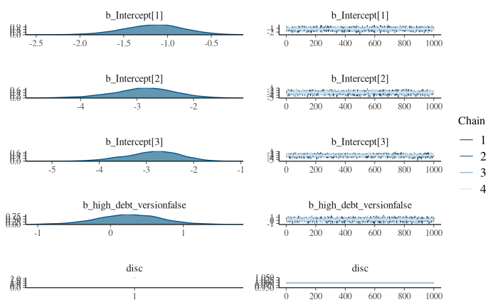

```r
plot(dropouts0, ask = FALSE)
```

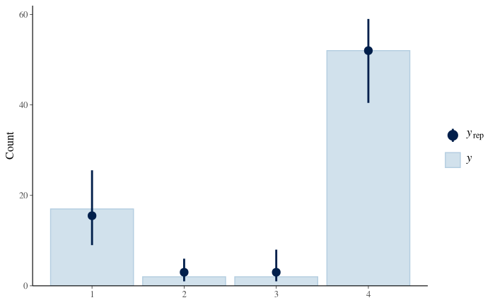

```r
pp_check(dropouts0, nsamples = 150, type = "bars")
```

```r
dropouts1 <- dropouts0.with("group")
summary(dropouts1)
```

```
 Family: sratio
  Links: mu = logit; disc = identity
Formula: task_completion ~ 1 + high_debt_version + group
   Data: as.data.frame(data) (Number of observations: 73)
Samples: 4 chains, each with iter = 2000; warmup = 1000; thin = 1;
         total post-warmup samples = 4000

Population-Level Effects:
                          Estimate Est.Error l-95% CI u-95% CI Rhat Bulk_ESS Tail_ESS
Intercept[1]                 -1.60      0.45    -2.50    -0.75 1.00     5135     2957
Intercept[2]                 -3.26      0.64    -4.58    -2.09 1.00     6099     2838
Intercept[3]                 -3.21      0.62    -4.48    -2.05 1.00     6584     3410
high_debt_versionfalse        0.26      0.43    -0.55     1.11 1.00     6765     2645
groupconsultants             -0.88      0.54    -1.94     0.16 1.00     5482     3178
groupfriends                 -0.39      0.55    -1.48     0.69 1.00     5511     3518
groupopen                    -1.22      0.73    -2.59     0.26 1.00     6757     3411
groupproductMcompany         -0.91      0.76    -2.35     0.64 1.00     6675     2992
groupprofessionalMcontact     0.38      0.88    -1.27     2.10 1.00     7171     3338
groupstudents                -0.09      0.53    -1.11     0.97 1.00     5368     3567

Family Specific Parameters:
     Estimate Est.Error l-95% CI u-95% CI Rhat Bulk_ESS Tail_ESS
disc     1.00      0.00     1.00     1.00 1.00     4000     4000

Samples were drawn using sample(hmc). For each parameter, Bulk_ESS
and Tail_ESS are effective sample size measures, and Rhat is the potential
scale reduction factor on split chains (at convergence, Rhat = 1).
```

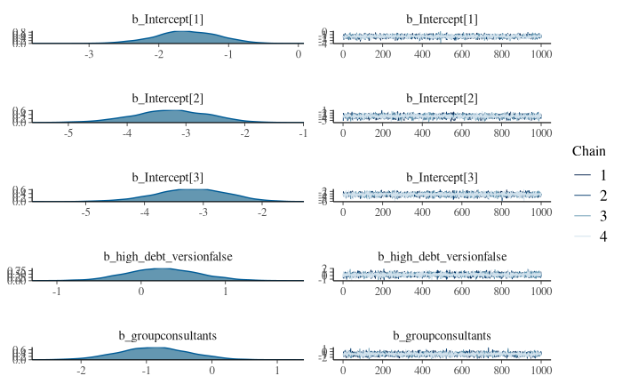

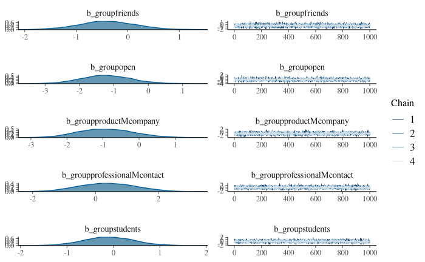

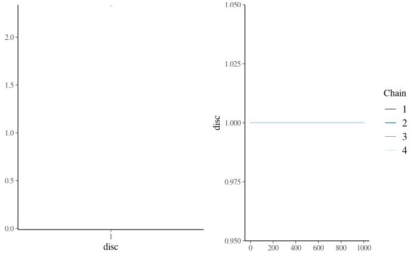

```r
plot(dropouts1, ask = FALSE)
```

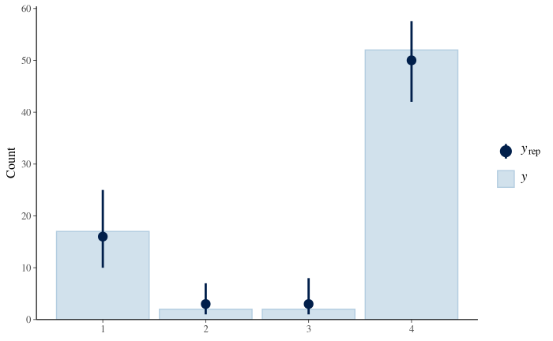

```r
pp_check(dropouts1, nsamples = 150, type = "bars")
```

```r
dropouts2 <- dropouts0.with(c("group", "education_field"))
summary(dropouts2)
```

```
 Family: sratio
  Links: mu = logit; disc = identity
Formula: task_completion ~ 1 + high_debt_version + education_field + group
   Data: as.data.frame(data) (Number of observations: 73)
Samples: 4 chains, each with iter = 2000; warmup = 1000; thin = 1;
         total post-warmup samples = 4000

Population-Level Effects:
                                     Estimate Est.Error l-95% CI u-95% CI Rhat Bulk_ESS Tail_ESS
Intercept[1]                            -1.93      0.70    -3.35    -0.60 1.00     3399     3037
Intercept[2]                            -3.52      0.84    -5.23    -1.93 1.00     4070     2962
Intercept[3]                            -3.48      0.81    -5.13    -1.91 1.00     4073     2959
high_debt_versionfalse                   0.23      0.45    -0.66     1.14 1.00     5957     2922
education_fieldComputerScience          -0.91      0.63    -2.14     0.29 1.00     3184     2989
education_fieldElectricalEngineering     0.33      0.91    -1.41     2.15 1.00     5963     3013
education_fieldIndustrialengineering    -0.58      0.93    -2.44     1.25 1.00     7064     3322
education_fieldInteractionDesign         0.62      0.85    -1.04     2.34 1.00     5507     3002
education_fieldNone                      0.62      0.85    -1.01     2.32 1.00     5796     2980
education_fieldSoftwareEngineering       0.21      0.64    -1.03     1.44 1.00     3208     3087
groupconsultants                        -1.05      0.62    -2.26     0.12 1.00     4274     2859
groupfriends                            -0.52      0.60    -1.67     0.68 1.00     4712     3220
groupopen                               -1.35      0.74    -2.79     0.07 1.00     5172     3251
groupproductMcompany                    -0.74      0.78    -2.22     0.74 1.00     6044     3170
groupprofessionalMcontact                0.56      0.85    -1.06     2.27 1.00     6748     3144
groupstudents                            0.04      0.55    -1.04     1.10 1.00     4727     3411

Family Specific Parameters:
     Estimate Est.Error l-95% CI u-95% CI Rhat Bulk_ESS Tail_ESS
disc     1.00      0.00     1.00     1.00 1.00     4000     4000

Samples were drawn using sample(hmc). For each parameter, Bulk_ESS
and Tail_ESS are effective sample size measures, and Rhat is the potential
scale reduction factor on split chains (at convergence, Rhat = 1).
```

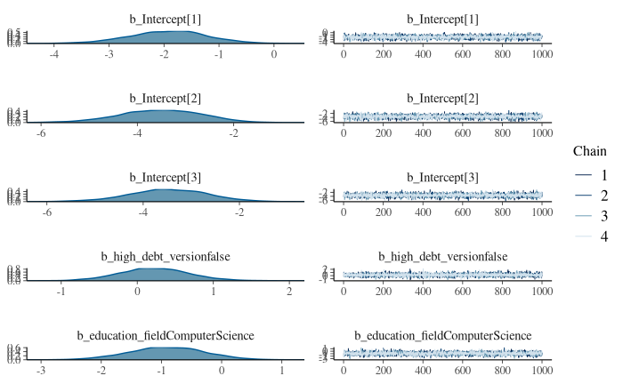

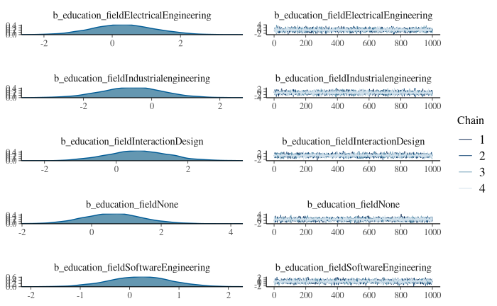

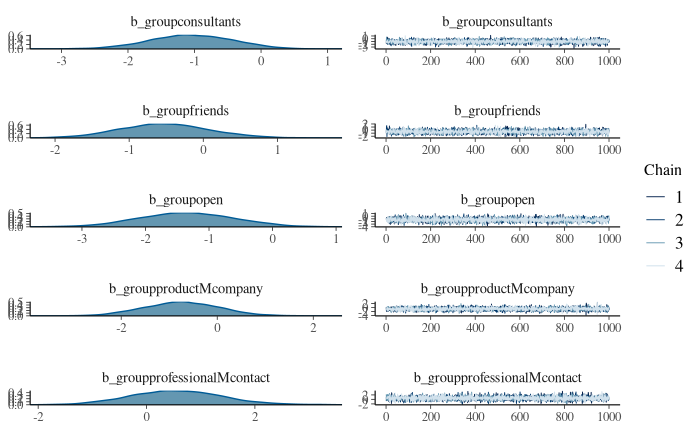

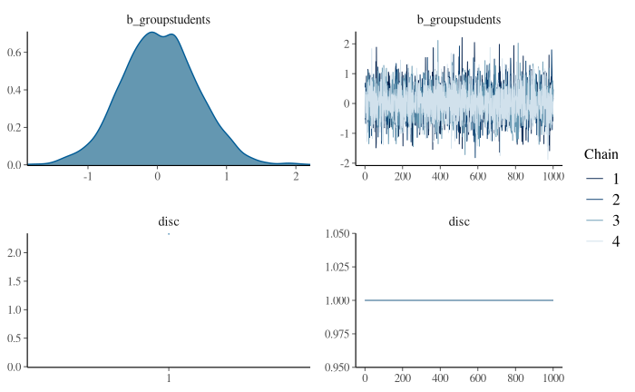

```r
plot(dropouts2, ask = FALSE)
```

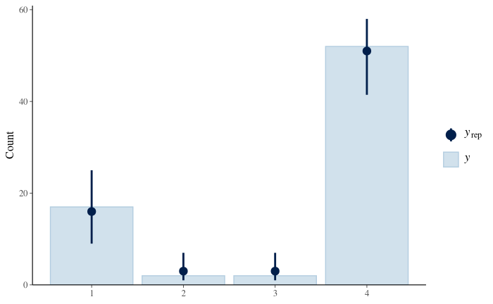

```r
pp_check(dropouts2, nsamples = 150, type = "bars")
```

```r
dropouts3 <- dropouts0.with(c("group", "education_field", "scenario"))
summary(dropouts3)
```

```
 Family: sratio
  Links: mu = logit; disc = identity
Formula: task_completion ~ 1 + high_debt_version + education_field + group + scenario
   Data: as.data.frame(data) (Number of observations: 73)
Samples: 4 chains, each with iter = 2000; warmup = 1000; thin = 1;
         total post-warmup samples = 4000

Population-Level Effects:
                                     Estimate Est.Error l-95% CI u-95% CI Rhat Bulk_ESS Tail_ESS
Intercept[1]                            -1.62      0.72    -3.00    -0.23 1.00     4027     3363
Intercept[2]                            -3.19      0.83    -4.82    -1.61 1.00     4359     3288
Intercept[3]                            -3.16      0.82    -4.85    -1.61 1.00     4459     3008
high_debt_versionfalse                   0.20      0.45    -0.70     1.05 1.00     6545     3271
education_fieldComputerScience          -0.89      0.62    -2.14     0.34 1.00     3542     3403
education_fieldElectricalEngineering     0.34      0.88    -1.34     2.09 1.00     5670     3102
education_fieldIndustrialengineering    -0.65      0.92    -2.41     1.12 1.00     6410     3193
education_fieldInteractionDesign         0.63      0.84    -0.98     2.29 1.00     6235     3329
education_fieldNone                      0.64      0.85    -0.97     2.36 1.00     6232     3007
education_fieldSoftwareEngineering       0.23      0.63    -1.02     1.45 1.00     3319     3275
groupconsultants                        -1.07      0.62    -2.31     0.15 1.00     4362     3238
groupfriends                            -0.49      0.56    -1.56     0.60 1.00     5268     3221
groupopen                               -1.40      0.77    -2.92     0.14 1.00     5453     2877
groupproductMcompany                    -0.75      0.78    -2.25     0.80 1.00     5471     2850
groupprofessionalMcontact                0.56      0.83    -1.03     2.25 1.00     7127     3185
groupstudents                            0.06      0.56    -1.06     1.18 1.00     5103     3247
scenariotickets                          0.69      0.46    -0.19     1.59 1.00     5674     3091

Family Specific Parameters:
     Estimate Est.Error l-95% CI u-95% CI Rhat Bulk_ESS Tail_ESS
disc     1.00      0.00     1.00     1.00 1.00     4000     4000

Samples were drawn using sample(hmc). For each parameter, Bulk_ESS
and Tail_ESS are effective sample size measures, and Rhat is the potential
scale reduction factor on split chains (at convergence, Rhat = 1).
```

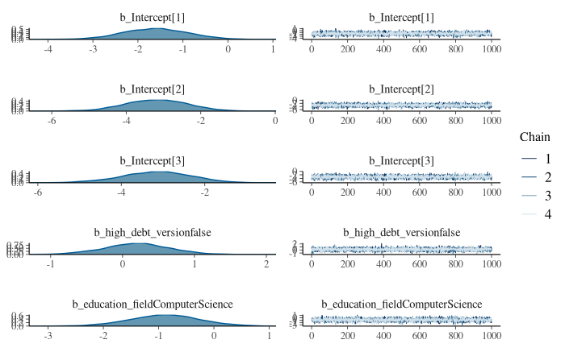

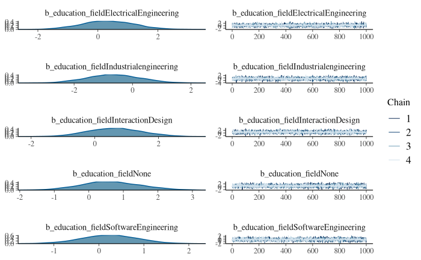

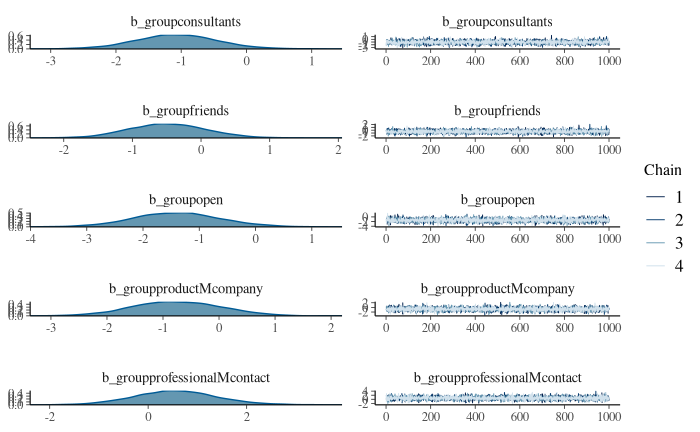

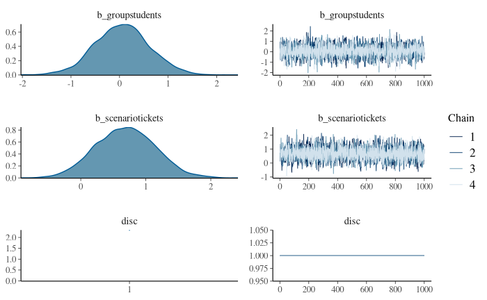

```r
plot(dropouts3, ask = FALSE)
```

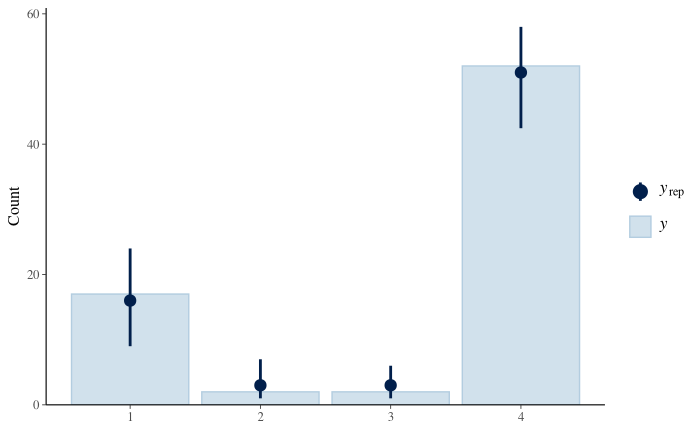

```r
pp_check(dropouts3, nsamples = 150, type = "bars")
```

```r
dropouts4 <- dropouts0.with(c("group", "education_field", "scenario", "workplace_pair_programming"))
summary(dropouts4)
```

```
 Family: sratio
  Links: mu = logit; disc = identity
Formula: task_completion ~ 1 + high_debt_version + education_field + group + scenario + workplace_pair_programming
   Data: as.data.frame(data) (Number of observations: 73)
Samples: 4 chains, each with iter = 2000; warmup = 1000; thin = 1;
         total post-warmup samples = 4000

Population-Level Effects:
                                     Estimate Est.Error l-95% CI u-95% CI Rhat Bulk_ESS Tail_ESS
Intercept[1]                            -1.01      0.79    -2.55     0.53 1.00     3665     3017
Intercept[2]                            -2.59      0.90    -4.41    -0.83 1.00     4140     3409
Intercept[3]                            -2.52      0.92    -4.29    -0.74 1.00     4002     3264
high_debt_versionfalse                   0.17      0.46    -0.72     1.06 1.00     6449     3215
education_fieldComputerScience          -0.88      0.61    -2.08     0.29 1.00     3672     3413
education_fieldElectricalEngineering     0.28      0.91    -1.45     2.10 1.00     6424     3190
education_fieldIndustrialengineering    -0.58      0.93    -2.44     1.24 1.00     5612     2924
education_fieldInteractionDesign         0.51      0.87    -1.16     2.28 1.00     5448     2987
education_fieldNone                      0.49      0.87    -1.12     2.18 1.00     5555     3212
education_fieldSoftwareEngineering       0.40      0.63    -0.85     1.64 1.00     3474     3045
groupconsultants                        -0.83      0.64    -2.05     0.38 1.00     4206     3281
groupfriends                            -0.35      0.58    -1.50     0.81 1.00     4301     2826
groupopen                               -1.25      0.76    -2.69     0.28 1.00     5947     3044
groupproductMcompany                    -0.80      0.80    -2.32     0.77 1.00     4859     3038
groupprofessionalMcontact                0.47      0.86    -1.16     2.20 1.00     6239     3079
groupstudents                            0.08      0.56    -1.01     1.19 1.00     4669     2923
scenariotickets                          0.73      0.47    -0.21     1.67 1.00     6693     2632
workplace_pair_programmingfalse          0.87      0.47    -0.07     1.77 1.00     5376     3113

Family Specific Parameters:
     Estimate Est.Error l-95% CI u-95% CI Rhat Bulk_ESS Tail_ESS
disc     1.00      0.00     1.00     1.00 1.00     4000     4000

Samples were drawn using sample(hmc). For each parameter, Bulk_ESS
and Tail_ESS are effective sample size measures, and Rhat is the potential
scale reduction factor on split chains (at convergence, Rhat = 1).
```

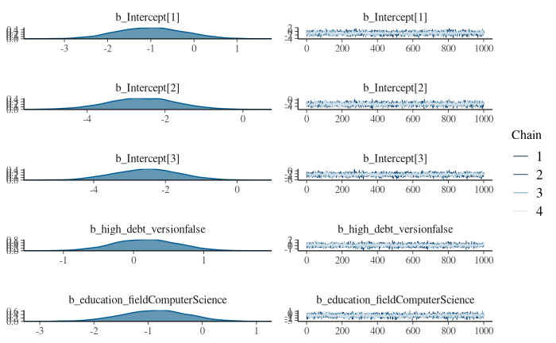

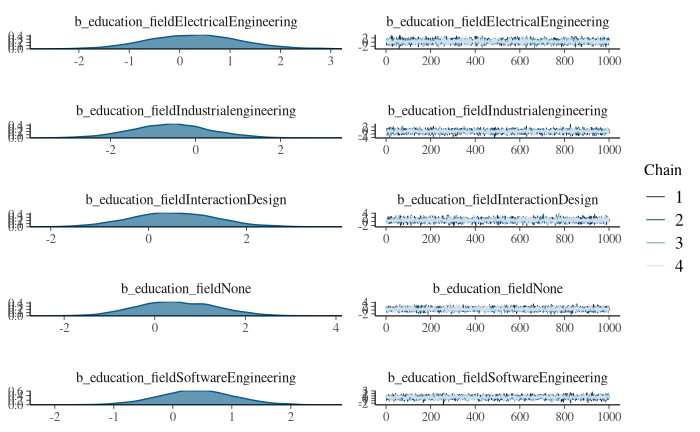

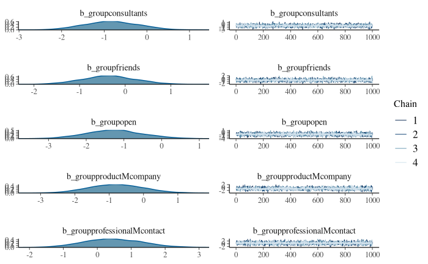

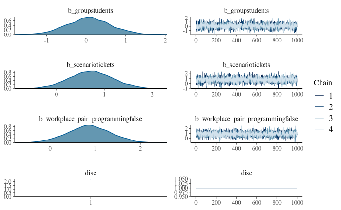

```r
plot(dropouts4, ask = FALSE)
```

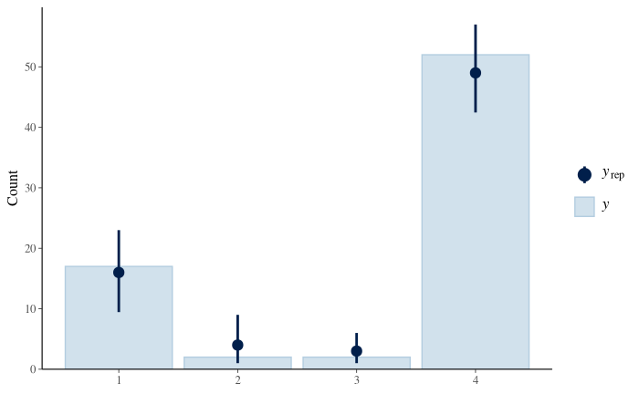

```r
pp_check(dropouts4, nsamples = 150, type = "bars")
```

### Final model

All models look nice. According to loo some of the more complex models perform better than the simpler ones. We can also see that the estimate for `high_debt_versionfalse` becomes slightly more uncertain with the more complex models. `dropouts2` has a good estimate and is not significantly worse than the best performing model according to loo.

## Interpreting the model

Extract posterior samples:

```r
post <- posterior_predict(dropouts2, newdata = data.frame(high_debt_version = c("false", "true"), group = NA, education_field = NA))
post.low <-  post[,1]
post.high <- post[,2]
post.diff <- post.high - post.low
```

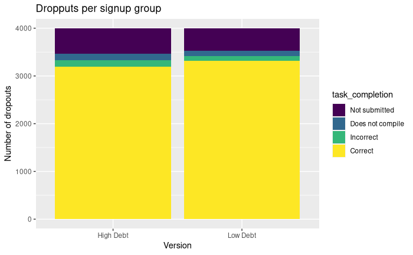

```r
data.frame(
  task_completion = factor(
    c(post.low, post.high),
    ordered = TRUE,
    levels = c(1, 2, 3, 4),
    labels = c("Not submitted", "Does not compile", "Incorrect", "Correct")
  ),
  debt_version = c(
    rep("Low Debt", length(post.low)),
    rep("High Debt", length(post.high))
  )
) %>%
  ggplot(aes(debt_version, fill=task_completion)) +
  geom_bar() +
  labs(title = "Dropputs per signup group") +
  ylab("Number of dropouts") +
  xlab("Version")
```

```r
sum(post.diff < 0)/length(post.diff)
```

```
[1] 0.16575
```

```r
sum(post.diff > 0)/length(post.diff)
```

```
[1] 0.13425
```